# Variation in coverage and uptake of antivirals and neutralising monoclonal antibodies by STP

This report describes the coverage and uptake of antivirals and neutralising monoclonal antibodies for the treatment of non-hospitalised patients with COVID-19 by STP. Note, that a) practice-STP mappings used to calculate the coverage are as of March 2020 and since then some borders and population sizes may have changed and b) the subset of the population covered by TPP in each STP may not be representative of the whole STP and c) STPs with less than 10% population coverage in TPP practices have been omitted.

### Overall coverage of COVID-19 treatment, by STP decile

Between **11-Dec-2021** and **28-Apr-2022**, a total of 99,560 non-hospitalised patients registered at a TPP practice in England were identified as potentially being eligible for receiving an antiviral or nMAB for treating COVID-19. Of these 99,560 potentially eligible patients, 17,990 (**18%**) received treatment from a CMDU.

STP (used as a proxy for CMDU) was available for 99,370 (100%) of eligible patients and 17,950 (100%) of treated patients with a total of 32 STPs identified. Of these 32 STPs, 6 were excluded due to having less than 10% population coverage in TPP practices; 2,652 eligible patients and 223 treated patients.

**Figure 1 Cumulative total of potentially eligible patients for receiving an antiviral or nMABs for treating COVID-19 since 11th December 2021, stratified by STP decile.** Patients are considered eligible on the date of their positive SARS-CoV-2 test. Note, the overall number in each group is likely to be an overestimation due to including SARS-CoV-2 infection confirmed by either lateral flow or PCR test (where only PCR-confirmed infections should have been treated according to guidance in effect prior to 10th February 2022), and potentially including non-symptomatic patients. Decile values relating to patient counts of 0-7 have been redacted.

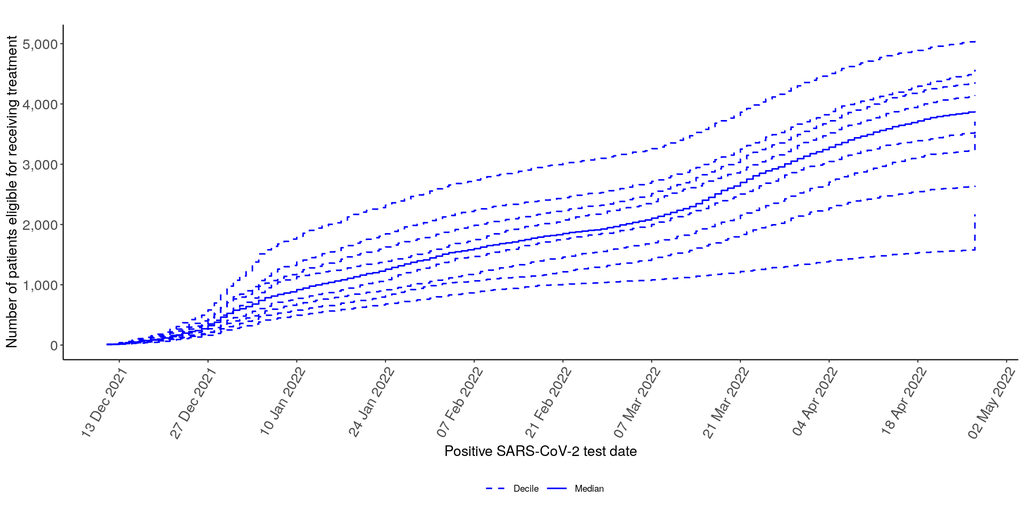

**Figure 2 Cumulative total of patients who received an antiviral or nMAB for treating COVID-19 since 16th December 2021, stratified by STP decile. Decile values relating to patient counts of 0-7 have been redacted.**

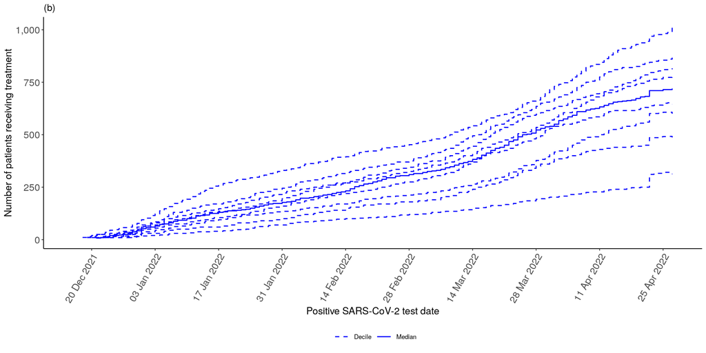

**Figure 3 Weekly proportion of eligible patients receiving an antiviral or nMAB for treating COVID-19 since 11th December 2021, stratified by STP decile.**

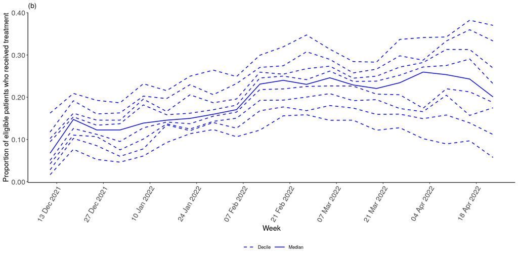

**Table 1 Count and proportion of potentially eligible patients in OpenSAFELY-TPP who have received treatment for COVID-19 since 16th December 2021, broken down by STP decile and treatment type.** Counts <8 have been redacted and counts >7 are rounded to the nearest 10; as a result percentages may not add up to 100%."

[output not shown]

* All percentages (%) are caluclated with 95% confidence intervals